# APdata_analysisMW

Maggie Westerland

2023-05-01

```r
load('final_df.Rdata')
```

```r
final_df <- final_df %>%
  mutate(pre_htn = as.factor(pre_htn)) %>%
  mutate(post_htn = as.factor(post_htn), levels(c('yes','no'))) %>%
  mutate(bmi_return = as.factor(bmi_return)) %>%
  mutate(gest_age_wks = as.numeric(gest_age_wks)) %>%
  mutate(ob_gravidity = as.character(ob_gravidity)) %>%
  mutate(ob_gravidity = as.factor(ob_gravidity)) %>%
  mutate(ob_parity = as.character(ob_parity)) %>%
  mutate(ob_parity = as.factor(ob_parity)) %>%
  mutate(ob_multiple_births = as.character(ob_multiple_births)) %>%
  mutate(ob_multiple_births = as.factor(ob_multiple_births)) %>%
  filter(delivery_method != 'Other') %>%
  mutate(delivery_method = as.character(delivery_method)) %>%
  mutate(delivery_method = as.factor(delivery_method)) %>%
  mutate(ob_gravidity = factor(ob_gravidity, levels = c(1,
                                                        2,
                                                        3,
                                                        4,
                                                        5,
                                                        6,
                                                        7,
                                                        8,
                                                        9,
                                                        10,
                                                        11,
                                                        12,
                                                        13,
                                                        14,
                                                        15,
                                                        16,
                                                        17,
                                                        18))) %>%
  mutate(ob_parity = factor(ob_parity, levels = c(1,
                                                  2,
                                                  3,
                                                  4,
                                                  5,
                                                  6,
                                                  7,
                                                  8,
                                                  9,
                                                  10,
                                                  11,
                                                  12))) %>%
  mutate(post_htn = case_when(
    post_htn == 'no' ~ 0,
    post_htn == 'yes' ~ 1
  )) %>%
  mutate(post_htn = as.factor(post_htn))
```

\ \ \

```r
final_df %>%
  select(mom_age_at_del,
         mom_race,
         mom_ethnicity,
         mom_marital_status,
         employment_status,
         preeclampsia,
         pregest_dm,
         gestational_dm,
         placental_abruption,
         maternal_dvt,
         gest_age_wks,
         delivery_method,
         #ob_gravidity,
         #ob_parity,
         ob_multiple_births,
         baby_count,
         mean_pre_bmi,
         mean_post_bmi,
         bmi_return
  ) %>%
  tbl_summary(
    by = bmi_return,
    missing_text = 'Missing'
  ) %>%
  add_p() %>%
  modify_header(label = "**Variable**") %>%
  bold_labels()
```

```
## 11553 observations missing `bmi_return` have been removed. To include these observations, use `forcats::fct_explicit_na()` on `bmi_return` column before passing to `tbl_summary()`.
```

| **Variable** | **no**, N = 3,059<sup>1</sup> | **yes**, N = 4,299<sup>1</sup> | **p-value**<sup>2</sup> |
| --- | --- | --- | --- |
| mom_age_at_del | 29.0 (25.0, 33.0) | 30.0 (27.0, 33.0) | <0.001 |
| mom_race |  |  | <0.001 |
| Black or African American | 762 (25%) | 654 (15%) |  |
| Other | 305 (10%) | 369 (8.6%) |  |
| White or Caucasian | 1,975 (65%) | 3,262 (76%) |  |
| Missing | 17 | 14 |  |
| mom_ethnicity |  |  | 0.049 |
| Hispanic | 179 (5.9%) | 206 (4.8%) |  |
| NH | 2,875 (94%) | 4,084 (95%) |  |
| Other | 0 (0%) | 0 (0%) |  |
| Missing | 5 | 9 |  |
| mom_marital_status |  |  | <0.001 |
| Divorced | 113 (3.7%) | 129 (3.0%) |  |
| Married | 1,798 (59%) | 3,129 (73%) |  |
| Other | 82 (2.7%) | 64 (1.5%) |  |
| Single | 1,065 (35%) | 976 (23%) |  |
| Missing | 1 | 1 |  |
| employment_status |  |  | <0.001 |
| Full Time | 1,661 (54%) | 2,530 (59%) |  |
| Not Employed | 850 (28%) | 968 (23%) |  |
| Other | 132 (4.3%) | 206 (4.8%) |  |
| Part Time | 409 (13%) | 583 (14%) |  |
| Missing | 7 | 12 |  |
| preeclampsia | 258 (8.4%) | 365 (8.5%) | >0.9 |
| pregest_dm | 5 (0.2%) | 3 (<0.1%) | 0.3 |
| gestational_dm | 57 (1.9%) | 52 (1.2%) | 0.022 |
| placental_abruption | 29 (0.9%) | 41 (1.0%) | >0.9 |
| maternal_dvt | 0 (0%) | 0 (0%) | >0.9 |
| gest_age_wks | 39.00 (37.57, 39.71) | 39.14 (38.29, 40.00) | <0.001 |
| Missing | 85 | 114 |  |
| delivery_method |  |  | 0.2 |
| C-Section | 885 (29%) | 1,220 (28%) |  |
| Operative Vaginal | 138 (4.5%) | 233 (5.4%) |  |
| Vaginal | 2,036 (67%) | 2,846 (66%) |  |
| ob_multiple_births |  |  | 0.8 |
| 0 | 2,719 (96%) | 3,769 (96%) |  |
| 1 | 111 (3.9%) | 140 (3.6%) |  |
| 2 | 3 (0.1%) | 3 (<0.1%) |  |
| 3 | 0 (0%) | 1 (<0.1%) |  |
| Missing | 226 | 386 |  |
| baby_count |  |  | 0.8 |
| 1 | 3,002 (98%) | 4,220 (98%) |  |
| 2 | 55 (1.8%) | 78 (1.8%) |  |
| 3 | 2 (<0.1%) | 1 (<0.1%) |  |
| mean_pre_bmi | 31 (26, 36) | 28 (25, 32) | <0.001 |
| mean_post_bmi | 32 (27, 38) | 25 (22, 29) | <0.001 |

<sup>1</sup> Median (IQR); n (%)  
<sup>2</sup> Wilcoxon rank sum test; Pearson's Chi-squared test; Fisher's exact test

```r
unweighted_mod <- glm(
   post_htn ~
    bmi_return +
    mom_age_at_del +
    mom_race +
    mom_ethnicity +
    mom_marital_status +
    employment_status +
    preeclampsia +
    pregest_dm +
    gestational_dm +
    placental_abruption +
    #maternal_dvt #+ # not enough obs
    gest_age_wks +
    delivery_method +
    ob_gravidity +
    ob_parity +
    ob_multiple_births +
    baby_count +
    mean_pre_bmi
    #mean_post_bmi not converging
  ,
  data = final_df,
  family = binomial(link = "logit"))

summary(unweighted_mod)
```

```
##
## Call:
## glm(formula = post_htn ~ bmi_return + mom_age_at_del + mom_race +
##     mom_ethnicity + mom_marital_status + employment_status +
##     preeclampsia + pregest_dm + gestational_dm + placental_abruption +
##     gest_age_wks + delivery_method + ob_gravidity + ob_parity +
##     ob_multiple_births + baby_count + mean_pre_bmi, family = binomial(link = "logit"),
##     data = final_df)
##
## Deviance Residuals:
##     Min       1Q   Median       3Q      Max
## -2.7369   0.2859   0.3827   0.5225   5.3024
##
## Coefficients:
##                                    Estimate Std. Error z value Pr(>|z|)
## (Intercept)                       1.780e+00  7.096e-01   2.508   0.0121 *
## bmi_returnyes                     3.566e-01  8.091e-02   4.408 1.05e-05 ***
## mom_age_at_del                   -8.290e-02  8.588e-03  -9.653  < 2e-16 ***
## mom_raceOther                     4.351e-01  1.715e-01   2.537   0.0112 *
## mom_raceWhite or Caucasian        6.551e-01  1.135e-01   5.774 7.76e-09 ***
## mom_ethnicityNH                   1.605e-01  1.906e-01   0.842   0.3997
## mom_marital_statusMarried         3.944e-01  1.989e-01   1.983   0.0474 *
## mom_marital_statusOther           3.325e-01  3.407e-01   0.976   0.3290
## mom_marital_statusSingle          6.896e-02  2.080e-01   0.332   0.7402
## employment_statusNot Employed    -1.888e-01  9.519e-02  -1.984   0.0473 *
## employment_statusOther           -3.648e-01  1.709e-01  -2.134   0.0328 *
## employment_statusPart Time        3.743e-02  1.263e-01   0.296   0.7670
## preeclampsiaYes                  -1.595e+00  1.087e-01 -14.676  < 2e-16 ***
## pregest_dmYes                     5.801e-01  1.106e+00   0.525   0.5999
## gestational_dmYes                -1.419e-01  2.737e-01  -0.518   0.6043
## placental_abruptionYes            4.112e-01  3.980e-01   1.033   0.3016
## gest_age_wks                      7.023e-02  1.196e-02   5.873 4.27e-09 ***
## delivery_methodOperative Vaginal  2.043e-01  2.164e-01   0.944   0.3451
## delivery_methodVaginal            1.733e-01  8.611e-02   2.012   0.0442 *
## ob_gravidity2                    -8.435e-02  1.297e-01  -0.650   0.5155
## ob_gravidity3                    -8.390e-02  1.569e-01  -0.535   0.5928
## ob_gravidity4                    -2.616e-01  1.828e-01  -1.431   0.1525
## ob_gravidity5                    -3.566e-01  2.177e-01  -1.638   0.1014
## ob_gravidity6                    -4.242e-01  2.682e-01  -1.582   0.1137
## ob_gravidity7                    -7.151e-01  3.314e-01  -2.158   0.0309 *
```

[output cut: 20 more lines]

```
## ob_multiple_births2              -6.724e-01  1.252e+00  -0.537   0.5913
## ob_multiple_births3               1.142e+01  8.827e+02   0.013   0.9897
## baby_count                        7.552e-01  3.138e-01   2.406   0.0161 *
## mean_pre_bmi                     -5.335e-02  5.164e-03 -10.332  < 2e-16 ***
## ---
## Signif. codes:  0 '***' 0.001 '**' 0.01 '*' 0.05 '.' 0.1 ' ' 1
##
## (Dispersion parameter for binomial family taken to be 1)
##
##     Null deviance: 5211.1  on 6336  degrees of freedom
## Residual deviance: 4373.0  on 6288  degrees of freedom
##   (12574 observations deleted due to missingness)
## AIC: 4471
##
## Number of Fisher Scoring iterations: 13
```

```r
unweighted_mod2 <- glm(
  post_htn ~
    bmi_return +
    mom_age_at_del +
    mom_race +
    mom_ethnicity +
    mom_marital_status +
    employment_status +
    preeclampsia +
    pregest_dm +
    gestational_dm +
    placental_abruption +
    #maternal_dvt #+ # not enough obs
    gest_age_wks +
    delivery_method +
    ob_gravidity +
    ob_parity +
    ob_multiple_births +
    baby_count +
    mean_pre_bmi
    #mean_post_bmi not converging
  ,
  data = unweighted_mod$model,
  family = binomial(link = "logit"))

step_unweight2 <- step(unweighted_mod2)
```

```
## Start:  AIC=4471.02
## post_htn ~ bmi_return + mom_age_at_del + mom_race + mom_ethnicity +
##     mom_marital_status + employment_status + preeclampsia + pregest_dm +
##     gestational_dm + placental_abruption + gest_age_wks + delivery_method +
##     ob_gravidity + ob_parity + ob_multiple_births + baby_count +
##     mean_pre_bmi
##
##                       Df Deviance    AIC
## - ob_gravidity        14   4385.5 4455.5
## - ob_parity           11   4380.1 4456.1
## - ob_multiple_births   3   4376.0 4468.0
## - gestational_dm       1   4373.3 4469.3
## - pregest_dm           1   4373.3 4469.3
## - mom_ethnicity        1   4373.7 4469.7
## - placental_abruption  1   4374.2 4470.2
## <none>                     4373.0 4471.0
## - delivery_method      2   4377.2 4471.2
## - employment_status    3   4381.0 4473.0
## - baby_count           1   4378.9 4474.9
## - mom_marital_status   3   4384.3 4476.3
## - bmi_return           1   4392.4 4488.4
## - mom_race             2   4406.4 4500.4
## - gest_age_wks         1   4405.9 4501.9
## - mom_age_at_del       1   4467.1 4563.1
## - mean_pre_bmi         1   4481.6 4577.6
## - preeclampsia         1   4575.0 4671.0
##
## Step:  AIC=4455.54
## post_htn ~ bmi_return + mom_age_at_del + mom_race + mom_ethnicity +
##     mom_marital_status + employment_status + preeclampsia + pregest_dm +
##     gestational_dm + placental_abruption + gest_age_wks + delivery_method +
##     ob_parity + ob_multiple_births + baby_count + mean_pre_bmi
##
##                       Df Deviance    AIC
## - ob_parity           11   4398.6 4446.6
## - ob_multiple_births   3   4388.4 4452.4
## - pregest_dm           1   4385.9 4453.9
## - gestational_dm       1   4385.9 4453.9
## - mom_ethnicity        1   4386.4 4454.4
## - placental_abruption  1   4386.9 4454.9
```

[output cut: 122 more lines]

```
##     employment_status + preeclampsia + gest_age_wks + delivery_method +
##     baby_count + mean_pre_bmi
##
##                      Df Deviance    AIC
## <none>                    4405.0 4439.0
## - delivery_method     2   4409.1 4439.1
## - baby_count          1   4408.0 4440.0
## - employment_status   3   4415.5 4443.5
## - mom_marital_status  3   4419.3 4447.3
## - bmi_return          1   4425.7 4457.7
## - gest_age_wks        1   4439.2 4471.2
## - mom_race            2   4448.4 4478.4
## - mean_pre_bmi        1   4520.6 4552.6
## - mom_age_at_del      1   4553.0 4585.0
## - preeclampsia        1   4600.8 4632.8
```

```r
summary(step_unweight2)
```

```
##
## Call:
## glm(formula = post_htn ~ bmi_return + mom_age_at_del + mom_race +
##     mom_marital_status + employment_status + preeclampsia + gest_age_wks +
##     delivery_method + baby_count + mean_pre_bmi, family = binomial(link = "logit"),
##     data = unweighted_mod$model)
##
## Deviance Residuals:
##     Min       1Q   Median       3Q      Max
## -2.7474   0.2913   0.3884   0.5226   5.4027
##
## Coefficients:
##                                    Estimate Std. Error z value Pr(>|z|)
## (Intercept)                       2.3786585  0.6538074   3.638 0.000275 ***
## bmi_returnyes                     0.3645681  0.0802354   4.544 5.53e-06 ***
## mom_age_at_del                   -0.0928983  0.0077380 -12.005  < 2e-16 ***
## mom_raceOther                     0.4242112  0.1530555   2.772 0.005578 **
## mom_raceWhite or Caucasian        0.7184014  0.1091830   6.580 4.71e-11 ***
## mom_marital_statusMarried         0.4380126  0.1944887   2.252 0.024314 *
## mom_marital_statusOther           0.3149422  0.3364554   0.936 0.349243
## mom_marital_statusSingle          0.0768532  0.2049372   0.375 0.707654
## employment_statusNot Employed    -0.2236321  0.0931632  -2.400 0.016376 *
## employment_statusOther           -0.4183186  0.1688414  -2.478 0.013228 *
## employment_statusPart Time        0.0005067  0.1254013   0.004 0.996776
## preeclampsiaYes                  -1.5479568  0.1068661 -14.485  < 2e-16 ***
## gest_age_wks                      0.0711114  0.0118007   6.026 1.68e-09 ***
## delivery_methodOperative Vaginal  0.2776892  0.2153825   1.289 0.197299
## delivery_methodVaginal            0.1535456  0.0846024   1.815 0.069538 .
## baby_count                        0.4102919  0.2445956   1.677 0.093458 .
## mean_pre_bmi                     -0.0545407  0.0051104 -10.673  < 2e-16 ***
## ---
## Signif. codes:  0 '***' 0.001 '**' 0.01 '*' 0.05 '.' 0.1 ' ' 1
##
## (Dispersion parameter for binomial family taken to be 1)
##
##     Null deviance: 5211.1  on 6336  degrees of freedom
## Residual deviance: 4405.0  on 6320  degrees of freedom
## AIC: 4439
##
## Number of Fisher Scoring iterations: 5
```

```r
tbl_regression(step_unweight2, exponentiate = T)
```

| **Characteristic** | **OR**<sup>1</sup> | **95% CI**<sup>1</sup> | **p-value** |
| --- | --- | --- | --- |
| bmi_return |  |  |  |
| no | — | — |  |
| yes | 1.44 | 1.23, 1.69 | <0.001 |
| mom_age_at_del | 0.91 | 0.90, 0.93 | <0.001 |
| mom_race |  |  |  |
| Black or African American | — | — |  |
| Other | 1.53 | 1.14, 2.07 | 0.006 |
| White or Caucasian | 2.05 | 1.66, 2.54 | <0.001 |
| mom_marital_status |  |  |  |
| Divorced | — | — |  |
| Married | 1.55 | 1.05, 2.25 | 0.024 |
| Other | 1.37 | 0.72, 2.70 | 0.3 |
| Single | 1.08 | 0.72, 1.60 | 0.7 |
| employment_status |  |  |  |
| Full Time | — | — |  |
| Not Employed | 0.80 | 0.67, 0.96 | 0.016 |
| Other | 0.66 | 0.48, 0.92 | 0.013 |
| Part Time | 1.00 | 0.79, 1.28 | >0.9 |
| preeclampsia |  |  |  |
| No | — | — |  |
| Yes | 0.21 | 0.17, 0.26 | <0.001 |
| gest_age_wks | 1.07 | 1.05, 1.10 | <0.001 |
| delivery_method |  |  |  |
| C-Section | — | — |  |
| Operative Vaginal | 1.32 | 0.88, 2.05 | 0.2 |
| Vaginal | 1.17 | 0.99, 1.38 | 0.070 |
| baby_count | 1.51 | 0.95, 2.48 | 0.093 |
| mean_pre_bmi | 0.95 | 0.94, 0.96 | <0.001 |

<sup>1</sup> OR = Odds Ratio, CI = Confidence Interval

ROC/AUC

```r
final_df$predicted <- predict(step_unweight2, newdata = final_df, type="response")

final_df_pred <- final_df[complete.cases(final_df[, c("predicted", "post_htn")]),]

pred <- prediction(final_df_pred$predicted, final_df_pred$post_htn)
perf <- performance(pred, "tpr", "fpr")

auc <- as.numeric(performance(pred, measure = "auc")@y.values)
auc
```

```
## [1] 0.7719156
```

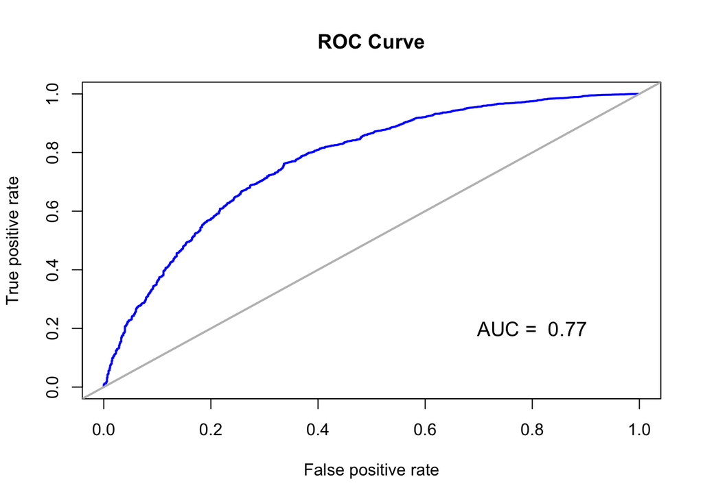

```r
plot(perf, main="ROC Curve", col="blue", lwd=2, xlim=c(0,1), ylim=c(0,1))
abline(0,1, lwd=2, col="gray")
text(0.8, 0.2, paste("AUC = ", round(auc, 2)), cex = 1.2)
```

data dictionary:

**patient_num**: *integer* unique to each patient

**dx_code**: *character* ICD-10 code for the diagnosis of hypertension if applicable, I10

**htn_dx_date**: *date* shifted date of patient diagnosis of hypertension if applicable, shifted by $\pm$ 10 days

**pre_htn**: *factor* yes if patient was diagnosed w/ hypertension before 12 months post-delivery, no if not

**post_htn**: *factor* yes if patient was diagnosed w/ hypertension between 13-72 months post-delivery, no if not

**mom_admit_dttm_shifted**: *date* date of the mother’s delivery admission

**mom_disch_dttm_shifted**: *date* date of the mother’s delivery discharge

**mom_los**: *integer* mom’s length of stay in days for the delivery encounter

**mom_age_at_del**: *date* mom’s age at delivery in years

**mom_marital_status**: *factor* mom’s current marital status: Divorced, Married, Other, Single

**mom_race**: *factor* mom’s current race: Black or African American, Other, White or Caucasian

**mom_ethnicity**: *factor* mom’s current ethnicity: Hispanic, NH (non-hispanic), Other

**mom_wt_oz**: *numeric* most recent mother weight up to delivery

**mom_bmi**: *numeric* most recent mother BMI up to delivery

**preeclampsia**: *factor* indicates presence of a preeclampsia diagnosis on the delivery encounter

**pregest_dm**: *factor* indicates presence of a pregestational diabetes diagnosis on the delivery encounter

**gestational_dm**: *factor* indicates presence of a gestational diabetes diagnosis on the delivery encounter

**placental_abruption**: *factor* indicates presence of a placental abruption diagnosis on the delivery encounter

**maternal_dvt**: *factor* indicates presence of a maternal deep vein thrombosis diagnosis on the delivery encounter

**baby_patient_num**: *integer* Masked MRN, the i2b2 patient number

**baby_yob_shifted**: *date* Baby’s year of birth

**baby_dob_shifted**: *date* Baby’s date of birth

**baby_dod_shifted**: *date* Baby’s date of death

**baby_admit_dttm_shifted**: *date* Date of the baby’s birth admission

**baby_disch_dttm_shifted**: *date* Date of the baby’s birth discharge

**baby_birth_ht_in**: *numeric* Baby’s birth height in inches

**baby_birth_wt_oz**: *numeric* Baby’s birth weight in ounces

**baby_birth_wt_gms**: *numeric* Baby’s birth weight in grams

**gest_age_wks**: *numeric* Baby’s gestational age in weeks and days divided 7

**delivery_method**: *factor* Name of the delivery method used for the birth: C-Section, Operative Vaginal, Vaginal, Other (not included in analyses)

**baby_sex**: *factor* baby’s current sex, male or female

**baby_race**: *factor* baby’s current race: Black or African American, Other, White or Caucasian

**baby_ethnicity**: *factor* baby’s current ethnicity: Hispanic, NH (non-hispanic), Other

**ob_gravidity**: *factor* Number of pregnancies documented on the first OB visit up to 90 days after the delivery

**ob_parity**: *factor* Number of viable offspring documented on the first OB visit up to 90 days after the delivery

**ob_multiple_births**: *factor* Number of multiple births documented on the first OB visit up to 90 days after the delivery

**mom_ht_cm**: *numeric* mom’s height in centimeters

**baby_count**: *integer* number of babies birthed in most recent birth

**diff_htn**: *numeric* number of days between diagnosis of hypertension and baby DOB

**measure_date_shifted**: *date* date of mom’s BMI measurement

**highest_diastolic**: *numeric* mom’s diastolic component of highest blood pressure up to delivery

**highest_systolic**: *date* mom’s systolic component of highest blood pressure up to delivery

**post_bmi_date**: *date* date of post-delivery BMI measurement

**pre_bmi_date**: *date* date of pre-delivery BMI measurement

**mean_pre_bmi**: *numeric* averaged BMI measured pre-delivery

**mean_post_bmi**: *numeric* averaged BMI measured post-delivery

**birth_date_shifted**: *date* mom’s birth date

**employment_status**: *factor* mom’s current employment status: Full Time, Part Time, Not Employed, Other

**bmi_return**: *factor* yes if mom returned to pre-delivery BMI, no if post-delivery BMI was at least 1 point higher than pre-delivery BMI